# REPORT ON HOW TO DEPLOY AI/ML CORONA CASE INTO THE REAL WORLD

# Phase 2 Provision

( This version may include code of Mark was getting support Ideas and experience knowledge during our solution 2nd winner hackathon of FruitBunchAI in TU/e Artificial Intelligent student association event) with a teammate about corona's mental health price.

The code got support from IBM and other friends with strength in the data science field. To convince the audience not to be confused.

I am a student and not a researcher. The work here might be on Github; therefore * this version is our data study project. No confusion in regulation and aim for changing the government rule.

The reader can see the topic:

https://bmrheijligers.medium.com/coronacalm-hackingmentalhealth-749d4a4e7af0

As the genuine challenge not decide to do Facial Recognition, and this version aim for Corona Measure.

- In this notebook, we will take deep into Covid Analytic for each region and how the case is active working. The data set is from data.rivm.nl Netherland, and substantial truth and high reputation. In the progression of how the government records covid, it is not highly precise due to the large number of people who haven't show or declare a test with Covid.

**Aim**:

- Understand covid measure and analytic of issues.
- Giving AI to predict the best measure method for NL.

```python
import pandas as pd
import numpy  as np
import matplotlib
from pyearth import Earth
from pyearth import export
import matplotlib.pyplot as plt
#from jupyterthemes import jtplot
#jtplot.style(theme='onedork')

%matplotlib inline
np.warnings.filterwarnings('ignore')

pd.__version__
# np.__version__
print('matplotlib: {}'. format(matplotlib. __version__))
```

```
matplotlib: 3.3.4
```

## Raw Data Cleaning and processing.

```python
# !wget -N https://data.rivm.nl/covid-19/COVID-19_casus_landelijk.json
# Pyspark support with big data and easy to show the frame.
from pyspark.sql import SparkSession

spark = SparkSession \
    .builder \
    .appName("Python Spark SQL basic example") \
    .config("spark.some.config.option", "some-value") \
    .getOrCreate()
```

```python
df4 = spark.read.options(header='True', inferSchema='True', delimiter=';').csv('/home/markn/my_project/corona/COVID-19_casus_landelijk.csv')
df4.show(10)
```

```
+-------------------+---------------+--------------------+--------+------+-------------+------------------+--------+-------------+------------------------+
|          Date_file|Date_statistics|Date_statistics_type|Agegroup|   Sex|     Province|Hospital_admission|Deceased|Week_of_death|Municipal_health_service|
+-------------------+---------------+--------------------+--------+------+-------------+------------------+--------+-------------+------------------------+
|2021-03-23 10:00:00|     2020-01-01|                 DOO|   40-49|Female|Noord-Holland|                No|      No|         null|           GGD Amsterdam|
|2021-03-23 10:00:00|     2020-01-01|                 DOO|   50-59|  Male|   Gelderland|                No|      No|         null|    Veiligheids- en G...|
|2021-03-23 10:00:00|     2020-01-01|                 DOO|   20-29|Female| Zuid-Holland|                No|      No|         null|     GGD Hollands-Midden|
|2021-03-23 10:00:00|     2020-01-01|                 DOO|   60-69|Female|Noord-Holland|                No|      No|         null|    GGD Hollands-Noorden|
|2021-03-23 10:00:00|     2020-01-04|                 DOO|   10-19|Female|   Gelderland|           Unknown|      No|         null|     GGD Gelderland-Zuid|
|2021-03-23 10:00:00|     2020-01-06|                 DOO|   30-39|  Male|      Limburg|           Unknown| Unknown|         null|        GGD Zuid-Limburg|
|2021-03-23 10:00:00|     2020-01-16|                 DOO|     0-9|Female| Zuid-Holland|                No|      No|         null|    GGD Rotterdam-Rij...|
|2021-03-23 10:00:00|     2020-01-20|                 DOO|   50-59|Female|   Gelderland|                No|      No|         null|     GGD Gelderland-Zuid|
|2021-03-23 10:00:00|     2020-01-20|                 DOO|     0-9|  Male|   Gelderland|                No|      No|         null|     GGD Gelderland-Zuid|
|2021-03-23 10:00:00|     2020-01-22|                 DOO|   80-89|Female| Zuid-Holland|           Unknown| Unknown|         null|     GGD Hollands-Midden|
+-------------------+---------------+--------------------+--------+------+-------------+------------------+--------+-------------+------------------------+
only showing top 10 rows
```

```python
df4.printSchema()
```

```
root
 |-- Date_file: string (nullable = true)
 |-- Date_statistics: string (nullable = true)
 |-- Date_statistics_type: string (nullable = true)
 |-- Agegroup: string (nullable = true)
 |-- Sex: string (nullable = true)
 |-- Province: string (nullable = true)
 |-- Hospital_admission: string (nullable = true)
 |-- Deceased: string (nullable = true)
 |-- Week_of_death: integer (nullable = true)
 |-- Municipal_health_service: string (nullable = true)
```

After checking the data set collum we have to know exactly where is the province of Netherlands.

```python
df4.select("Province").distinct().show(truncate=False)
```

```
+-------------+
|Province     |
+-------------+
|Overijssel   |
|Flevoland    |
|Zeeland      |
|Noord-Brabant|
|Fryslân      |
|Noord-Holland|
|Gelderland   |
|Utrecht      |
|Limburg      |
|Drenthe      |
|Zuid-Holland |
|Groningen    |
+-------------+
```

```python
df = df4.toPandas()
df.head(10)
```

|  | Date_file | Date_statistics | Date_statistics_type | Agegroup | Sex | Province | Hospital_admission | Deceased | Week_of_death | Municipal_health_service |
| --- | --- | --- | --- | --- | --- | --- | --- | --- | --- | --- |
| 0 | 2021-03-23 10:00:00 | 2020-01-01 | DOO | 40-49 | Female | Noord-Holland | No | No | NaN | GGD Amsterdam |
| 1 | 2021-03-23 10:00:00 | 2020-01-01 | DOO | 50-59 | Male | Gelderland | No | No | NaN | Veiligheids- en Gezondheidsregio Gelderland-Mi... |
| 2 | 2021-03-23 10:00:00 | 2020-01-01 | DOO | 20-29 | Female | Zuid-Holland | No | No | NaN | GGD Hollands-Midden |
| 3 | 2021-03-23 10:00:00 | 2020-01-01 | DOO | 60-69 | Female | Noord-Holland | No | No | NaN | GGD Hollands-Noorden |
| 4 | 2021-03-23 10:00:00 | 2020-01-04 | DOO | 10-19 | Female | Gelderland | Unknown | No | NaN | GGD Gelderland-Zuid |
| 5 | 2021-03-23 10:00:00 | 2020-01-06 | DOO | 30-39 | Male | Limburg | Unknown | Unknown | NaN | GGD Zuid-Limburg |
| 6 | 2021-03-23 10:00:00 | 2020-01-16 | DOO | 0-9 | Female | Zuid-Holland | No | No | NaN | GGD Rotterdam-Rijnmond |
| 7 | 2021-03-23 10:00:00 | 2020-01-20 | DOO | 50-59 | Female | Gelderland | No | No | NaN | GGD Gelderland-Zuid |
| 8 | 2021-03-23 10:00:00 | 2020-01-20 | DOO | 0-9 | Male | Gelderland | No | No | NaN | GGD Gelderland-Zuid |
| 9 | 2021-03-23 10:00:00 | 2020-01-22 | DOO | 80-89 | Female | Zuid-Holland | Unknown | Unknown | NaN | GGD Hollands-Midden |

```python
# df = pd.read_csv('/home/markn/my_project/corona/COVID-19_casus_landelijk.csv', sep=';', parse_dates=[0, 1], infer_datetime_format=True)
# df.info()
# from pandas.compat import StringIO

# df = pd.read_csv(StringIO(df1), parse_dates=[0, 1])

# df1.info()
df['Date_file'] = df['Date_file'].astype('datetime64[ns]')
df['Date_statistics'] = df['Date_statistics'].astype('datetime64[ns]')
df.info()
```

```
<class 'pandas.core.frame.DataFrame'>
RangeIndex: 1213366 entries, 0 to 1213365
Data columns (total 10 columns):
Date_file                   1213366 non-null datetime64[ns]
Date_statistics             1213366 non-null datetime64[ns]
Date_statistics_type        1213366 non-null object
Agegroup                    1213366 non-null object
Sex                         1213366 non-null object
Province                    1213366 non-null object
Hospital_admission          1213366 non-null object
Deceased                    1213366 non-null object
Week_of_death               16338 non-null float64
Municipal_health_service    1213366 non-null object
dtypes: datetime64[ns](2), float64(1), object(7)
memory usage: 92.6+ MB
```

```python
df.count()
```

```
Date_file                   1213366
Date_statistics             1213366
Date_statistics_type        1213366
Agegroup                    1213366
Sex                         1213366
Province                    1213366
Hospital_admission          1213366
Deceased                    1213366
Week_of_death                 16338
Municipal_health_service    1213366
dtype: int64
```

```python
daterep = 'Date_statistics'
region  = 'Municipal_health_service'
cases   = 'cases'
deaths  = 'Deceased'
#we assign the difference collums for date,
lastdate = df[daterep].max() - pd.Timedelta('7 days')

df[cases]  = 1
df[deaths] = df[deaths].apply(lambda x: 1 if x == 'Yes' else 0)
df
```

|  | Date_file | Date_statistics | Date_statistics_type | Agegroup | Sex | Province | Hospital_admission | Deceased | Week_of_death | Municipal_health_service | cases |
| --- | --- | --- | --- | --- | --- | --- | --- | --- | --- | --- | --- |
| 0 | 2021-03-23 10:00:00 | 2020-01-01 | DOO | 40-49 | Female | Noord-Holland | No | 0 | NaN | GGD Amsterdam | 1 |
| 1 | 2021-03-23 10:00:00 | 2020-01-01 | DOO | 50-59 | Male | Gelderland | No | 0 | NaN | Veiligheids- en Gezondheidsregio Gelderland-Mi... | 1 |
| 2 | 2021-03-23 10:00:00 | 2020-01-01 | DOO | 20-29 | Female | Zuid-Holland | No | 0 | NaN | GGD Hollands-Midden | 1 |
| 3 | 2021-03-23 10:00:00 | 2020-01-01 | DOO | 60-69 | Female | Noord-Holland | No | 0 | NaN | GGD Hollands-Noorden | 1 |
| 4 | 2021-03-23 10:00:00 | 2020-01-04 | DOO | 10-19 | Female | Gelderland | Unknown | 0 | NaN | GGD Gelderland-Zuid | 1 |
| 5 | 2021-03-23 10:00:00 | 2020-01-06 | DOO | 30-39 | Male | Limburg | Unknown | 0 | NaN | GGD Zuid-Limburg | 1 |
| 6 | 2021-03-23 10:00:00 | 2020-01-16 | DOO | 0-9 | Female | Zuid-Holland | No | 0 | NaN | GGD Rotterdam-Rijnmond | 1 |
| 7 | 2021-03-23 10:00:00 | 2020-01-20 | DOO | 50-59 | Female | Gelderland | No | 0 | NaN | GGD Gelderland-Zuid | 1 |
| 8 | 2021-03-23 10:00:00 | 2020-01-20 | DOO | 0-9 | Male | Gelderland | No | 0 | NaN | GGD Gelderland-Zuid | 1 |
| 9 | 2021-03-23 10:00:00 | 2020-01-22 | DOO | 80-89 | Female | Zuid-Holland | Unknown | 0 | NaN | GGD Hollands-Midden | 1 |
| 10 | 2021-03-23 10:00:00 | 2020-01-24 | DOO | 40-49 | Male | Limburg | No | 0 | NaN | GGD Zuid-Limburg | 1 |
| 11 | 2021-03-23 10:00:00 | 2020-01-25 | DOO | 50-59 | Male | Drenthe | No | 0 | NaN | GGD Drenthe | 1 |
| 12 | 2021-03-23 10:00:00 | 2020-01-26 | DOO | 50-59 | Male | Groningen | No | 0 | NaN | GGD Groningen | 1 |
| 13 | 2021-03-23 10:00:00 | 2020-01-26 | DOO | 50-59 | Male | Noord-Brabant | No | 0 | NaN | GGD West-Brabant | 1 |
| 14 | 2021-03-23 10:00:00 | 2020-01-27 | DOO | 50-59 | Female | Zuid-Holland | No | 0 | NaN | GGD Haaglanden | 1 |
| 15 | 2021-03-23 10:00:00 | 2020-01-27 | DOO | 60-69 | Male | Gelderland | No | 0 | NaN | Veiligheids- en Gezondheidsregio Gelderland-Mi... | 1 |
| 16 | 2021-03-23 10:00:00 | 2020-01-27 | DOO | 20-29 | Male | Groningen | No | 0 | NaN | GGD Groningen | 1 |
| 17 | 2021-03-23 10:00:00 | 2020-01-29 | DOO | 80-89 | Male | Overijssel | No | 0 | NaN | GGD Regio Twente | 1 |
| 18 | 2021-03-23 10:00:00 | 2020-01-31 | DOO | 80-89 | Male | Noord-Brabant | Yes | 1 | 202015.0 | GGD Brabant-Zuidoost | 1 |
| 19 | 2021-03-23 10:00:00 | 2020-01-31 | DOO | 90+ | Female | Noord-Holland | No | 0 | NaN | GGD Amsterdam | 1 |
| 20 | 2021-03-23 10:00:00 | 2020-01-31 | DOO | 50-59 | Male | Overijssel | No | 0 | NaN | GGD Regio Twente | 1 |
| 21 | 2021-03-23 10:00:00 | 2020-02-01 | DOO | 60-69 | Female | Limburg | Yes | 0 | NaN | GGD Limburg-Noord | 1 |
| 22 | 2021-03-23 10:00:00 | 2020-02-01 | DOO | 60-69 | Female | Overijssel | Yes | 0 | NaN | GGD IJsselland | 1 |
| 23 | 2021-03-23 10:00:00 | 2020-02-01 | DOO | 50-59 | Female | Zuid-Holland | No | 0 | NaN | GGD Hollands-Midden | 1 |
| 24 | 2021-03-23 10:00:00 | 2020-02-03 | DOO | 50-59 | Male | Noord-Brabant | Unknown | 0 | NaN | GGD Hart voor Brabant | 1 |
| 25 | 2021-03-23 10:00:00 | 2020-02-03 | DOO | 80-89 | Female | Overijssel | Unknown | 0 | NaN | GGD IJsselland | 1 |
| 26 | 2021-03-23 10:00:00 | 2020-02-06 | DOO | 20-29 | Female | Noord-Brabant | No | 0 | NaN | GGD Brabant-Zuidoost | 1 |
| 27 | 2021-03-23 10:00:00 | 2020-02-06 | DOO | 80-89 | Male | Noord-Brabant | Unknown | 0 | NaN | GGD Hart voor Brabant | 1 |
| 28 | 2021-03-23 10:00:00 | 2020-02-07 | DOO | 70-79 | Male | Noord-Brabant | No | 0 | NaN | GGD Hart voor Brabant | 1 |
| 29 | 2021-03-23 10:00:00 | 2020-02-07 | DOO | 70-79 | Female | Noord-Brabant | Yes | 0 | NaN | GGD Brabant-Zuidoost | 1 |
| ... | ... | ... | ... | ... | ... | ... | ... | ... | ... | ... | ... |
| 1213336 | 2021-03-23 10:00:00 | 2021-03-23 | DPL | 10-19 | Female | Utrecht | Unknown | 0 | NaN | GGD Regio Utrecht | 1 |
| 1213337 | 2021-03-23 10:00:00 | 2021-03-23 | DPL | 70-79 | Male | Zuid-Holland | Unknown | 0 | NaN | GGD Hollands-Midden | 1 |
| 1213338 | 2021-03-23 10:00:00 | 2021-03-23 | DPL | 30-39 | Male | Noord-Holland | Unknown | 0 | NaN | GGD Kennemerland | 1 |
| 1213339 | 2021-03-23 10:00:00 | 2021-03-23 | DPL | 20-29 | Male | Gelderland | Unknown | 0 | NaN | Veiligheids- en Gezondheidsregio Gelderland-Mi... | 1 |
| 1213340 | 2021-03-23 10:00:00 | 2021-03-23 | DPL | 50-59 | Female | Noord-Brabant | Unknown | 0 | NaN | GGD Hart voor Brabant | 1 |
| 1213341 | 2021-03-23 10:00:00 | 2021-03-23 | DPL | 70-79 | Female | Overijssel | Unknown | 0 | NaN | GGD IJsselland | 1 |
| 1213342 | 2021-03-23 10:00:00 | 2021-03-23 | DPL | 60-69 | Male | Noord-Brabant | Unknown | 0 | NaN | GGD Hart voor Brabant | 1 |
| 1213343 | 2021-03-23 10:00:00 | 2021-03-23 | DPL | 50-59 | Male | Noord-Brabant | Unknown | 0 | NaN | GGD Hart voor Brabant | 1 |
| 1213344 | 2021-03-23 10:00:00 | 2021-03-23 | DPL | 60-69 | Female | Noord-Brabant | Unknown | 0 | NaN | GGD Brabant-Zuidoost | 1 |
| 1213345 | 2021-03-23 10:00:00 | 2021-03-23 | DON | 50-59 | Female | Zuid-Holland | Unknown | 0 | NaN | GGD Haaglanden | 1 |
| 1213346 | 2021-03-23 10:00:00 | 2021-03-23 | DPL | 20-29 | Male | Noord-Brabant | Unknown | 0 | NaN | GGD Hart voor Brabant | 1 |
| 1213347 | 2021-03-23 10:00:00 | 2021-03-23 | DON | 60-69 | Female | Zuid-Holland | Unknown | 0 | NaN | GGD Hollands-Midden | 1 |
| 1213348 | 2021-03-23 10:00:00 | 2021-03-23 | DPL | 60-69 | Female | Zuid-Holland | Unknown | 0 | NaN | Dienst Gezondheid & Jeugd ZHZ | 1 |
| 1213349 | 2021-03-23 10:00:00 | 2021-03-23 | DPL | 50-59 | Male | Noord-Brabant | Unknown | 0 | NaN | GGD Hart voor Brabant | 1 |
| 1213350 | 2021-03-23 10:00:00 | 2021-03-23 | DPL | 50-59 | Male | Noord-Brabant | Unknown | 0 | NaN | GGD Hart voor Brabant | 1 |
| 1213351 | 2021-03-23 10:00:00 | 2021-03-23 | DPL | 50-59 | Female | Zuid-Holland | Unknown | 0 | NaN | GGD Rotterdam-Rijnmond | 1 |
| 1213352 | 2021-03-23 10:00:00 | 2021-03-23 | DPL | 0-9 | Female | Zuid-Holland | Unknown | 0 | NaN | GGD Hollands-Midden | 1 |
| 1213353 | 2021-03-23 10:00:00 | 2021-03-23 | DPL | 50-59 | Female | Noord-Brabant | Unknown | 0 | NaN | GGD Hart voor Brabant | 1 |
| 1213354 | 2021-03-23 10:00:00 | 2021-03-23 | DPL | 10-19 | Male | Zuid-Holland | Unknown | 0 | NaN | GGD Haaglanden | 1 |
| 1213355 | 2021-03-23 10:00:00 | 2021-03-23 | DON | 50-59 | Female | Noord-Holland | Unknown | 0 | NaN | GGD Gooi en Vechtstreek | 1 |
| 1213356 | 2021-03-23 10:00:00 | 2021-03-23 | DPL | 50-59 | Female | Noord-Brabant | Unknown | 0 | NaN | GGD Hart voor Brabant | 1 |
| 1213357 | 2021-03-23 10:00:00 | 2021-03-23 | DPL | 50-59 | Male | Zuid-Holland | Unknown | 0 | NaN | GGD Haaglanden | 1 |
| 1213358 | 2021-03-23 10:00:00 | 2021-03-23 | DPL | 10-19 | Female | Zuid-Holland | Unknown | 0 | NaN | GGD Haaglanden | 1 |
| 1213359 | 2021-03-23 10:00:00 | 2021-03-23 | DPL | 0-9 | Female | Utrecht | Unknown | 0 | NaN | GGD Regio Utrecht | 1 |
| 1213360 | 2021-03-23 10:00:00 | 2021-03-23 | DPL | 40-49 | Female | Zuid-Holland | Unknown | 0 | NaN | GGD Hollands-Midden | 1 |
| 1213361 | 2021-03-23 10:00:00 | 2021-03-23 | DPL | 60-69 | Male | Noord-Brabant | Unknown | 0 | NaN | GGD Hart voor Brabant | 1 |
| 1213362 | 2021-03-23 10:00:00 | 2021-03-23 | DPL | 70-79 | Female | Noord-Brabant | Unknown | 0 | NaN | GGD Hart voor Brabant | 1 |
| 1213363 | 2021-03-23 10:00:00 | 2021-03-23 | DON | 40-49 | Female | Zuid-Holland | Unknown | 0 | NaN | GGD Hollands-Midden | 1 |
| 1213364 | 2021-03-23 10:00:00 | 2021-03-23 | DPL | 30-39 | Female | Noord-Brabant | Unknown | 0 | NaN | GGD Hart voor Brabant | 1 |
| 1213365 | 2021-03-23 10:00:00 | 2021-03-23 | DPL | 10-19 | Male | Zuid-Holland | Unknown | 0 | NaN | Dienst Gezondheid & Jeugd ZHZ | 1 |

1213366 rows × 11 columns

```python
df_geo = df.pivot_table(index=daterep, columns=region, values=[cases, deaths], aggfunc='sum').fillna(0)
df_geo['cases']
```

| Municipal_health_service Date_statistics | Dienst Gezondheid & Jeugd ZHZ | GGD Amsterdam | GGD Brabant-Zuidoost | GGD Drenthe | GGD Flevoland | GGD Fryslân | GGD Gelderland-Zuid | GGD Gooi en Vechtstreek | GGD Groningen | GGD Haaglanden | ... | GGD Limburg-Noord | GGD Noord- en Oost-Gelderland | GGD Regio Twente | GGD Regio Utrecht | GGD Rotterdam-Rijnmond | GGD West-Brabant | GGD Zaanstreek/Waterland | GGD Zeeland | GGD Zuid-Limburg | Veiligheids- en Gezondheidsregio Gelderland-Midden |
| --- | --- | --- | --- | --- | --- | --- | --- | --- | --- | --- | --- | --- | --- | --- | --- | --- | --- | --- | --- | --- | --- |
| 2020-01-01 | 0.0 | 1.0 | 0.0 | 0.0 | 0.0 | 0.0 | 0.0 | 0.0 | 0.0 | 0.0 | ... | 0.0 | 0.0 | 0.0 | 0.0 | 0.0 | 0.0 | 0.0 | 0.0 | 0.0 | 1.0 |
| 2020-01-04 | 0.0 | 0.0 | 0.0 | 0.0 | 0.0 | 0.0 | 1.0 | 0.0 | 0.0 | 0.0 | ... | 0.0 | 0.0 | 0.0 | 0.0 | 0.0 | 0.0 | 0.0 | 0.0 | 0.0 | 0.0 |
| 2020-01-06 | 0.0 | 0.0 | 0.0 | 0.0 | 0.0 | 0.0 | 0.0 | 0.0 | 0.0 | 0.0 | ... | 0.0 | 0.0 | 0.0 | 0.0 | 0.0 | 0.0 | 0.0 | 0.0 | 1.0 | 0.0 |
| 2020-01-16 | 0.0 | 0.0 | 0.0 | 0.0 | 0.0 | 0.0 | 0.0 | 0.0 | 0.0 | 0.0 | ... | 0.0 | 0.0 | 0.0 | 0.0 | 1.0 | 0.0 | 0.0 | 0.0 | 0.0 | 0.0 |
| 2020-01-20 | 0.0 | 0.0 | 0.0 | 0.0 | 0.0 | 0.0 | 2.0 | 0.0 | 0.0 | 0.0 | ... | 0.0 | 0.0 | 0.0 | 0.0 | 0.0 | 0.0 | 0.0 | 0.0 | 0.0 | 0.0 |
| 2020-01-22 | 0.0 | 0.0 | 0.0 | 0.0 | 0.0 | 0.0 | 0.0 | 0.0 | 0.0 | 0.0 | ... | 0.0 | 0.0 | 0.0 | 0.0 | 0.0 | 0.0 | 0.0 | 0.0 | 0.0 | 0.0 |
| 2020-01-24 | 0.0 | 0.0 | 0.0 | 0.0 | 0.0 | 0.0 | 0.0 | 0.0 | 0.0 | 0.0 | ... | 0.0 | 0.0 | 0.0 | 0.0 | 0.0 | 0.0 | 0.0 | 0.0 | 1.0 | 0.0 |
| 2020-01-25 | 0.0 | 0.0 | 0.0 | 1.0 | 0.0 | 0.0 | 0.0 | 0.0 | 0.0 | 0.0 | ... | 0.0 | 0.0 | 0.0 | 0.0 | 0.0 | 0.0 | 0.0 | 0.0 | 0.0 | 0.0 |
| 2020-01-26 | 0.0 | 0.0 | 0.0 | 0.0 | 0.0 | 0.0 | 0.0 | 0.0 | 1.0 | 0.0 | ... | 0.0 | 0.0 | 0.0 | 0.0 | 0.0 | 1.0 | 0.0 | 0.0 | 0.0 | 0.0 |
| 2020-01-27 | 0.0 | 0.0 | 0.0 | 0.0 | 0.0 | 0.0 | 0.0 | 0.0 | 1.0 | 1.0 | ... | 0.0 | 0.0 | 0.0 | 0.0 | 0.0 | 0.0 | 0.0 | 0.0 | 0.0 | 1.0 |
| 2020-01-29 | 0.0 | 0.0 | 0.0 | 0.0 | 0.0 | 0.0 | 0.0 | 0.0 | 0.0 | 0.0 | ... | 0.0 | 0.0 | 1.0 | 0.0 | 0.0 | 0.0 | 0.0 | 0.0 | 0.0 | 0.0 |
| 2020-01-31 | 0.0 | 1.0 | 1.0 | 0.0 | 0.0 | 0.0 | 0.0 | 0.0 | 0.0 | 0.0 | ... | 0.0 | 0.0 | 1.0 | 0.0 | 0.0 | 0.0 | 0.0 | 0.0 | 0.0 | 0.0 |
| 2020-02-01 | 0.0 | 0.0 | 0.0 | 0.0 | 0.0 | 0.0 | 0.0 | 0.0 | 0.0 | 0.0 | ... | 1.0 | 0.0 | 0.0 | 0.0 | 0.0 | 0.0 | 0.0 | 0.0 | 0.0 | 0.0 |
| 2020-02-03 | 0.0 | 0.0 | 0.0 | 0.0 | 0.0 | 0.0 | 0.0 | 0.0 | 0.0 | 0.0 | ... | 0.0 | 0.0 | 0.0 | 0.0 | 0.0 | 0.0 | 0.0 | 0.0 | 0.0 | 0.0 |
| 2020-02-06 | 0.0 | 0.0 | 1.0 | 0.0 | 0.0 | 0.0 | 0.0 | 0.0 | 0.0 | 0.0 | ... | 0.0 | 0.0 | 0.0 | 0.0 | 0.0 | 0.0 | 0.0 | 0.0 | 0.0 | 0.0 |
| 2020-02-07 | 0.0 | 0.0 | 1.0 | 0.0 | 0.0 | 0.0 | 0.0 | 0.0 | 0.0 | 0.0 | ... | 0.0 | 0.0 | 0.0 | 0.0 | 0.0 | 0.0 | 0.0 | 0.0 | 0.0 | 0.0 |
| 2020-02-10 | 0.0 | 0.0 | 0.0 | 0.0 | 0.0 | 0.0 | 2.0 | 0.0 | 0.0 | 1.0 | ... | 0.0 | 0.0 | 0.0 | 0.0 | 0.0 | 0.0 | 1.0 | 0.0 | 0.0 | 0.0 |
| 2020-02-11 | 0.0 | 0.0 | 0.0 | 0.0 | 0.0 | 0.0 | 0.0 | 1.0 | 0.0 | 0.0 | ... | 0.0 | 0.0 | 0.0 | 0.0 | 0.0 | 0.0 | 0.0 | 0.0 | 0.0 | 0.0 |
| 2020-02-12 | 0.0 | 0.0 | 0.0 | 0.0 | 0.0 | 1.0 | 0.0 | 1.0 | 0.0 | 0.0 | ... | 0.0 | 0.0 | 0.0 | 0.0 | 0.0 | 0.0 | 0.0 | 0.0 | 0.0 | 0.0 |
| 2020-02-13 | 0.0 | 1.0 | 0.0 | 0.0 | 0.0 | 0.0 | 0.0 | 0.0 | 0.0 | 0.0 | ... | 0.0 | 0.0 | 0.0 | 0.0 | 0.0 | 0.0 | 0.0 | 0.0 | 0.0 | 0.0 |
| 2020-02-14 | 0.0 | 1.0 | 0.0 | 1.0 | 0.0 | 0.0 | 1.0 | 0.0 | 0.0 | 0.0 | ... | 0.0 | 0.0 | 1.0 | 0.0 | 0.0 | 0.0 | 0.0 | 0.0 | 0.0 | 0.0 |
| 2020-02-15 | 0.0 | 0.0 | 0.0 | 0.0 | 1.0 | 0.0 | 0.0 | 0.0 | 0.0 | 0.0 | ... | 0.0 | 0.0 | 1.0 | 0.0 | 0.0 | 0.0 | 0.0 | 0.0 | 0.0 | 0.0 |
| 2020-02-16 | 0.0 | 0.0 | 0.0 | 0.0 | 0.0 | 0.0 | 0.0 | 0.0 | 0.0 | 0.0 | ... | 1.0 | 0.0 | 0.0 | 0.0 | 0.0 | 1.0 | 0.0 | 0.0 | 0.0 | 0.0 |
| 2020-02-17 | 0.0 | 0.0 | 0.0 | 0.0 | 0.0 | 0.0 | 0.0 | 0.0 | 0.0 | 0.0 | ... | 0.0 | 0.0 | 0.0 | 1.0 | 0.0 | 0.0 | 0.0 | 0.0 | 0.0 | 0.0 |
| 2020-02-18 | 0.0 | 0.0 | 0.0 | 0.0 | 0.0 | 0.0 | 0.0 | 0.0 | 0.0 | 0.0 | ... | 0.0 | 0.0 | 0.0 | 0.0 | 0.0 | 0.0 | 0.0 | 0.0 | 0.0 | 0.0 |
| 2020-02-19 | 0.0 | 0.0 | 0.0 | 0.0 | 0.0 | 0.0 | 1.0 | 1.0 | 0.0 | 0.0 | ... | 0.0 | 0.0 | 0.0 | 1.0 | 0.0 | 0.0 | 0.0 | 0.0 | 1.0 | 0.0 |
| 2020-02-20 | 0.0 | 2.0 | 0.0 | 0.0 | 1.0 | 0.0 | 0.0 | 0.0 | 0.0 | 0.0 | ... | 0.0 | 0.0 | 0.0 | 1.0 | 0.0 | 1.0 | 0.0 | 0.0 | 1.0 | 1.0 |
| 2020-02-21 | 1.0 | 0.0 | 1.0 | 0.0 | 0.0 | 0.0 | 1.0 | 0.0 | 0.0 | 0.0 | ... | 0.0 | 0.0 | 0.0 | 1.0 | 0.0 | 1.0 | 0.0 | 0.0 | 0.0 | 0.0 |
| 2020-02-22 | 0.0 | 1.0 | 0.0 | 0.0 | 0.0 | 0.0 | 1.0 | 0.0 | 0.0 | 0.0 | ... | 0.0 | 0.0 | 0.0 | 0.0 | 1.0 | 0.0 | 0.0 | 0.0 | 1.0 | 0.0 |
| 2020-02-23 | 0.0 | 0.0 | 0.0 | 0.0 | 0.0 | 0.0 | 0.0 | 0.0 | 0.0 | 0.0 | ... | 3.0 | 0.0 | 0.0 | 1.0 | 1.0 | 0.0 | 1.0 | 0.0 | 0.0 | 0.0 |
| ... | ... | ... | ... | ... | ... | ... | ... | ... | ... | ... | ... | ... | ... | ... | ... | ... | ... | ... | ... | ... | ... |
| 2021-02-22 | 173.0 | 284.0 | 260.0 | 126.0 | 88.0 | 204.0 | 172.0 | 71.0 | 156.0 | 234.0 | ... | 170.0 | 159.0 | 134.0 | 383.0 | 403.0 | 174.0 | 155.0 | 89.0 | 112.0 | 127.0 |
| 2021-02-23 | 184.0 | 229.0 | 250.0 | 113.0 | 85.0 | 175.0 | 158.0 | 71.0 | 144.0 | 253.0 | ... | 146.0 | 155.0 | 139.0 | 374.0 | 368.0 | 153.0 | 139.0 | 97.0 | 92.0 | 91.0 |
| 2021-02-24 | 169.0 | 246.0 | 283.0 | 161.0 | 74.0 | 166.0 | 149.0 | 75.0 | 169.0 | 233.0 | ... | 159.0 | 202.0 | 120.0 | 335.0 | 361.0 | 130.0 | 138.0 | 96.0 | 110.0 | 130.0 |
| 2021-02-25 | 167.0 | 240.0 | 192.0 | 114.0 | 78.0 | 139.0 | 150.0 | 62.0 | 124.0 | 202.0 | ... | 154.0 | 140.0 | 117.0 | 292.0 | 352.0 | 150.0 | 149.0 | 91.0 | 105.0 | 85.0 |
| 2021-02-26 | 152.0 | 210.0 | 220.0 | 124.0 | 74.0 | 125.0 | 142.0 | 68.0 | 145.0 | 237.0 | ... | 130.0 | 146.0 | 107.0 | 297.0 | 343.0 | 123.0 | 144.0 | 82.0 | 103.0 | 86.0 |
| 2021-02-27 | 154.0 | 232.0 | 203.0 | 119.0 | 94.0 | 137.0 | 148.0 | 76.0 | 129.0 | 171.0 | ... | 156.0 | 151.0 | 102.0 | 291.0 | 320.0 | 143.0 | 124.0 | 75.0 | 103.0 | 106.0 |
| 2021-02-28 | 178.0 | 209.0 | 179.0 | 119.0 | 89.0 | 143.0 | 137.0 | 75.0 | 125.0 | 210.0 | ... | 154.0 | 140.0 | 82.0 | 300.0 | 307.0 | 120.0 | 114.0 | 83.0 | 83.0 | 99.0 |
| 2021-03-01 | 162.0 | 306.0 | 236.0 | 123.0 | 101.0 | 170.0 | 150.0 | 74.0 | 143.0 | 272.0 | ... | 177.0 | 189.0 | 88.0 | 300.0 | 437.0 | 152.0 | 152.0 | 108.0 | 93.0 | 122.0 |
| 2021-03-02 | 192.0 | 283.0 | 251.0 | 138.0 | 94.0 | 163.0 | 169.0 | 73.0 | 134.0 | 244.0 | ... | 177.0 | 196.0 | 112.0 | 309.0 | 361.0 | 147.0 | 139.0 | 91.0 | 98.0 | 144.0 |
| 2021-03-03 | 165.0 | 262.0 | 264.0 | 118.0 | 80.0 | 182.0 | 158.0 | 96.0 | 115.0 | 253.0 | ... | 177.0 | 187.0 | 113.0 | 299.0 | 385.0 | 173.0 | 142.0 | 112.0 | 124.0 | 119.0 |
| 2021-03-04 | 186.0 | 260.0 | 277.0 | 102.0 | 78.0 | 153.0 | 151.0 | 60.0 | 106.0 | 211.0 | ... | 143.0 | 159.0 | 95.0 | 263.0 | 379.0 | 165.0 | 135.0 | 113.0 | 95.0 | 105.0 |
| 2021-03-05 | 165.0 | 295.0 | 244.0 | 129.0 | 99.0 | 192.0 | 128.0 | 62.0 | 128.0 | 244.0 | ... | 164.0 | 171.0 | 134.0 | 329.0 | 428.0 | 147.0 | 157.0 | 115.0 | 100.0 | 139.0 |
| 2021-03-06 | 169.0 | 301.0 | 249.0 | 122.0 | 67.0 | 201.0 | 139.0 | 63.0 | 133.0 | 280.0 | ... | 165.0 | 194.0 | 138.0 | 330.0 | 413.0 | 171.0 | 128.0 | 101.0 | 83.0 | 132.0 |
| 2021-03-07 | 179.0 | 280.0 | 242.0 | 114.0 | 87.0 | 166.0 | 149.0 | 67.0 | 113.0 | 250.0 | ... | 173.0 | 197.0 | 131.0 | 361.0 | 427.0 | 143.0 | 115.0 | 111.0 | 106.0 | 152.0 |
| 2021-03-08 | 181.0 | 327.0 | 275.0 | 165.0 | 104.0 | 187.0 | 186.0 | 61.0 | 142.0 | 318.0 | ... | 157.0 | 259.0 | 133.0 | 425.0 | 547.0 | 168.0 | 164.0 | 143.0 | 118.0 | 166.0 |
| 2021-03-09 | 228.0 | 317.0 | 289.0 | 138.0 | 113.0 | 197.0 | 175.0 | 77.0 | 126.0 | 301.0 | ... | 201.0 | 249.0 | 164.0 | 454.0 | 501.0 | 169.0 | 178.0 | 143.0 | 121.0 | 154.0 |
| 2021-03-10 | 246.0 | 313.0 | 309.0 | 187.0 | 104.0 | 264.0 | 183.0 | 60.0 | 169.0 | 360.0 | ... | 217.0 | 243.0 | 132.0 | 475.0 | 521.0 | 192.0 | 169.0 | 126.0 | 151.0 | 149.0 |
| 2021-03-11 | 243.0 | 308.0 | 274.0 | 160.0 | 97.0 | 214.0 | 175.0 | 53.0 | 143.0 | 330.0 | ... | 203.0 | 261.0 | 139.0 | 348.0 | 531.0 | 185.0 | 157.0 | 134.0 | 129.0 | 138.0 |
| 2021-03-12 | 215.0 | 305.0 | 293.0 | 170.0 | 104.0 | 214.0 | 212.0 | 57.0 | 146.0 | 330.0 | ... | 206.0 | 248.0 | 148.0 | 407.0 | 537.0 | 204.0 | 151.0 | 149.0 | 127.0 | 145.0 |
| 2021-03-13 | 225.0 | 298.0 | 337.0 | 163.0 | 110.0 | 216.0 | 201.0 | 60.0 | 140.0 | 366.0 | ... | 223.0 | 256.0 | 133.0 | 367.0 | 520.0 | 211.0 | 131.0 | 122.0 | 117.0 | 141.0 |
| 2021-03-14 | 214.0 | 268.0 | 251.0 | 144.0 | 93.0 | 171.0 | 177.0 | 50.0 | 130.0 | 330.0 | ... | 200.0 | 221.0 | 115.0 | 383.0 | 494.0 | 170.0 | 147.0 | 134.0 | 118.0 | 161.0 |
| 2021-03-15 | 297.0 | 359.0 | 283.0 | 177.0 | 96.0 | 244.0 | 189.0 | 67.0 | 160.0 | 344.0 | ... | 230.0 | 311.0 | 151.0 | 411.0 | 565.0 | 214.0 | 203.0 | 154.0 | 147.0 | 160.0 |
| 2021-03-16 | 192.0 | 313.0 | 288.0 | 222.0 | 132.0 | 241.0 | 203.0 | 63.0 | 154.0 | 401.0 | ... | 238.0 | 313.0 | 129.0 | 450.0 | 524.0 | 225.0 | 161.0 | 127.0 | 152.0 | 161.0 |
| 2021-03-17 | 223.0 | 347.0 | 305.0 | 177.0 | 88.0 | 249.0 | 188.0 | 60.0 | 150.0 | 344.0 | ... | 222.0 | 293.0 | 150.0 | 467.0 | 506.0 | 247.0 | 186.0 | 138.0 | 170.0 | 199.0 |
| 2021-03-18 | 209.0 | 305.0 | 254.0 | 151.0 | 91.0 | 160.0 | 161.0 | 71.0 | 128.0 | 318.0 | ... | 226.0 | 249.0 | 136.0 | 380.0 | 510.0 | 217.0 | 173.0 | 137.0 | 155.0 | 146.0 |
| 2021-03-19 | 209.0 | 256.0 | 265.0 | 142.0 | 91.0 | 176.0 | 150.0 | 59.0 | 93.0 | 316.0 | ... | 190.0 | 214.0 | 115.0 | 340.0 | 349.0 | 158.0 | 142.0 | 103.0 | 139.0 | 107.0 |
| 2021-03-20 | 166.0 | 160.0 | 250.0 | 92.0 | 45.0 | 120.0 | 125.0 | 38.0 | 53.0 | 233.0 | ... | 133.0 | 156.0 | 91.0 | 299.0 | 259.0 | 117.0 | 109.0 | 65.0 | 81.0 | 102.0 |
| 2021-03-21 | 214.0 | 111.0 | 262.0 | 61.0 | 35.0 | 63.0 | 85.0 | 29.0 | 46.0 | 141.0 | ... | 85.0 | 112.0 | 45.0 | 225.0 | 465.0 | 60.0 | 76.0 | 65.0 | 58.0 | 60.0 |
| 2021-03-22 | 123.0 | 148.0 | 138.0 | 38.0 | 22.0 | 38.0 | 126.0 | 11.0 | 90.0 | 141.0 | ... | 23.0 | 189.0 | 33.0 | 206.0 | 329.0 | 23.0 | 89.0 | 14.0 | 57.0 | 107.0 |
| 2021-03-23 | 32.0 | 11.0 | 14.0 | 1.0 | 0.0 | 1.0 | 42.0 | 1.0 | 16.0 | 19.0 | ... | 0.0 | 53.0 | 21.0 | 50.0 | 12.0 | 0.0 | 58.0 | 0.0 | 16.0 | 26.0 |

424 rows × 25 columns

```python
new_index = pd.date_range(df_geo.index.min(), df_geo.index.max() + pd.Timedelta('365 days'))
df_geo = df_geo.reindex(new_index)
df_geo
```

| Municipal_health_service | Deceased Dienst Gezondheid & Jeugd ZHZ | Deceased GGD Amsterdam | Deceased GGD Brabant-Zuidoost | Deceased GGD Drenthe | Deceased GGD Flevoland | Deceased GGD Fryslân | Deceased GGD Gelderland-Zuid | Deceased GGD Gooi en Vechtstreek | Deceased GGD Groningen | Deceased GGD Haaglanden | ... | cases GGD Limburg-Noord | cases GGD Noord- en Oost-Gelderland | cases GGD Regio Twente | cases GGD Regio Utrecht | cases GGD Rotterdam-Rijnmond | cases GGD West-Brabant | cases GGD Zaanstreek/Waterland | cases GGD Zeeland | cases GGD Zuid-Limburg | cases Veiligheids- en Gezondheidsregio Gelderland-Midden |
| --- | --- | --- | --- | --- | --- | --- | --- | --- | --- | --- | --- | --- | --- | --- | --- | --- | --- | --- | --- | --- | --- |
| 2020-01-01 | 0.0 | 0.0 | 0.0 | 0.0 | 0.0 | 0.0 | 0.0 | 0.0 | 0.0 | 0.0 | ... | 0.0 | 0.0 | 0.0 | 0.0 | 0.0 | 0.0 | 0.0 | 0.0 | 0.0 | 1.0 |
| 2020-01-02 | NaN | NaN | NaN | NaN | NaN | NaN | NaN | NaN | NaN | NaN | ... | NaN | NaN | NaN | NaN | NaN | NaN | NaN | NaN | NaN | NaN |
| 2020-01-03 | NaN | NaN | NaN | NaN | NaN | NaN | NaN | NaN | NaN | NaN | ... | NaN | NaN | NaN | NaN | NaN | NaN | NaN | NaN | NaN | NaN |
| 2020-01-04 | 0.0 | 0.0 | 0.0 | 0.0 | 0.0 | 0.0 | 0.0 | 0.0 | 0.0 | 0.0 | ... | 0.0 | 0.0 | 0.0 | 0.0 | 0.0 | 0.0 | 0.0 | 0.0 | 0.0 | 0.0 |
| 2020-01-05 | NaN | NaN | NaN | NaN | NaN | NaN | NaN | NaN | NaN | NaN | ... | NaN | NaN | NaN | NaN | NaN | NaN | NaN | NaN | NaN | NaN |
| 2020-01-06 | 0.0 | 0.0 | 0.0 | 0.0 | 0.0 | 0.0 | 0.0 | 0.0 | 0.0 | 0.0 | ... | 0.0 | 0.0 | 0.0 | 0.0 | 0.0 | 0.0 | 0.0 | 0.0 | 1.0 | 0.0 |
| 2020-01-07 | NaN | NaN | NaN | NaN | NaN | NaN | NaN | NaN | NaN | NaN | ... | NaN | NaN | NaN | NaN | NaN | NaN | NaN | NaN | NaN | NaN |
| 2020-01-08 | NaN | NaN | NaN | NaN | NaN | NaN | NaN | NaN | NaN | NaN | ... | NaN | NaN | NaN | NaN | NaN | NaN | NaN | NaN | NaN | NaN |
| 2020-01-09 | NaN | NaN | NaN | NaN | NaN | NaN | NaN | NaN | NaN | NaN | ... | NaN | NaN | NaN | NaN | NaN | NaN | NaN | NaN | NaN | NaN |
| 2020-01-10 | NaN | NaN | NaN | NaN | NaN | NaN | NaN | NaN | NaN | NaN | ... | NaN | NaN | NaN | NaN | NaN | NaN | NaN | NaN | NaN | NaN |
| 2020-01-11 | NaN | NaN | NaN | NaN | NaN | NaN | NaN | NaN | NaN | NaN | ... | NaN | NaN | NaN | NaN | NaN | NaN | NaN | NaN | NaN | NaN |
| 2020-01-12 | NaN | NaN | NaN | NaN | NaN | NaN | NaN | NaN | NaN | NaN | ... | NaN | NaN | NaN | NaN | NaN | NaN | NaN | NaN | NaN | NaN |
| 2020-01-13 | NaN | NaN | NaN | NaN | NaN | NaN | NaN | NaN | NaN | NaN | ... | NaN | NaN | NaN | NaN | NaN | NaN | NaN | NaN | NaN | NaN |
| 2020-01-14 | NaN | NaN | NaN | NaN | NaN | NaN | NaN | NaN | NaN | NaN | ... | NaN | NaN | NaN | NaN | NaN | NaN | NaN | NaN | NaN | NaN |
| 2020-01-15 | NaN | NaN | NaN | NaN | NaN | NaN | NaN | NaN | NaN | NaN | ... | NaN | NaN | NaN | NaN | NaN | NaN | NaN | NaN | NaN | NaN |
| 2020-01-16 | 0.0 | 0.0 | 0.0 | 0.0 | 0.0 | 0.0 | 0.0 | 0.0 | 0.0 | 0.0 | ... | 0.0 | 0.0 | 0.0 | 0.0 | 1.0 | 0.0 | 0.0 | 0.0 | 0.0 | 0.0 |
| 2020-01-17 | NaN | NaN | NaN | NaN | NaN | NaN | NaN | NaN | NaN | NaN | ... | NaN | NaN | NaN | NaN | NaN | NaN | NaN | NaN | NaN | NaN |
| 2020-01-18 | NaN | NaN | NaN | NaN | NaN | NaN | NaN | NaN | NaN | NaN | ... | NaN | NaN | NaN | NaN | NaN | NaN | NaN | NaN | NaN | NaN |
| 2020-01-19 | NaN | NaN | NaN | NaN | NaN | NaN | NaN | NaN | NaN | NaN | ... | NaN | NaN | NaN | NaN | NaN | NaN | NaN | NaN | NaN | NaN |
| 2020-01-20 | 0.0 | 0.0 | 0.0 | 0.0 | 0.0 | 0.0 | 0.0 | 0.0 | 0.0 | 0.0 | ... | 0.0 | 0.0 | 0.0 | 0.0 | 0.0 | 0.0 | 0.0 | 0.0 | 0.0 | 0.0 |
| 2020-01-21 | NaN | NaN | NaN | NaN | NaN | NaN | NaN | NaN | NaN | NaN | ... | NaN | NaN | NaN | NaN | NaN | NaN | NaN | NaN | NaN | NaN |
| 2020-01-22 | 0.0 | 0.0 | 0.0 | 0.0 | 0.0 | 0.0 | 0.0 | 0.0 | 0.0 | 0.0 | ... | 0.0 | 0.0 | 0.0 | 0.0 | 0.0 | 0.0 | 0.0 | 0.0 | 0.0 | 0.0 |
| 2020-01-23 | NaN | NaN | NaN | NaN | NaN | NaN | NaN | NaN | NaN | NaN | ... | NaN | NaN | NaN | NaN | NaN | NaN | NaN | NaN | NaN | NaN |
| 2020-01-24 | 0.0 | 0.0 | 0.0 | 0.0 | 0.0 | 0.0 | 0.0 | 0.0 | 0.0 | 0.0 | ... | 0.0 | 0.0 | 0.0 | 0.0 | 0.0 | 0.0 | 0.0 | 0.0 | 1.0 | 0.0 |
| 2020-01-25 | 0.0 | 0.0 | 0.0 | 0.0 | 0.0 | 0.0 | 0.0 | 0.0 | 0.0 | 0.0 | ... | 0.0 | 0.0 | 0.0 | 0.0 | 0.0 | 0.0 | 0.0 | 0.0 | 0.0 | 0.0 |
| 2020-01-26 | 0.0 | 0.0 | 0.0 | 0.0 | 0.0 | 0.0 | 0.0 | 0.0 | 0.0 | 0.0 | ... | 0.0 | 0.0 | 0.0 | 0.0 | 0.0 | 1.0 | 0.0 | 0.0 | 0.0 | 0.0 |
| 2020-01-27 | 0.0 | 0.0 | 0.0 | 0.0 | 0.0 | 0.0 | 0.0 | 0.0 | 0.0 | 0.0 | ... | 0.0 | 0.0 | 0.0 | 0.0 | 0.0 | 0.0 | 0.0 | 0.0 | 0.0 | 1.0 |
| 2020-01-28 | NaN | NaN | NaN | NaN | NaN | NaN | NaN | NaN | NaN | NaN | ... | NaN | NaN | NaN | NaN | NaN | NaN | NaN | NaN | NaN | NaN |
| 2020-01-29 | 0.0 | 0.0 | 0.0 | 0.0 | 0.0 | 0.0 | 0.0 | 0.0 | 0.0 | 0.0 | ... | 0.0 | 0.0 | 1.0 | 0.0 | 0.0 | 0.0 | 0.0 | 0.0 | 0.0 | 0.0 |
| 2020-01-30 | NaN | NaN | NaN | NaN | NaN | NaN | NaN | NaN | NaN | NaN | ... | NaN | NaN | NaN | NaN | NaN | NaN | NaN | NaN | NaN | NaN |
| ... | ... | ... | ... | ... | ... | ... | ... | ... | ... | ... | ... | ... | ... | ... | ... | ... | ... | ... | ... | ... | ... |
| 2022-02-22 | NaN | NaN | NaN | NaN | NaN | NaN | NaN | NaN | NaN | NaN | ... | NaN | NaN | NaN | NaN | NaN | NaN | NaN | NaN | NaN | NaN |
| 2022-02-23 | NaN | NaN | NaN | NaN | NaN | NaN | NaN | NaN | NaN | NaN | ... | NaN | NaN | NaN | NaN | NaN | NaN | NaN | NaN | NaN | NaN |
| 2022-02-24 | NaN | NaN | NaN | NaN | NaN | NaN | NaN | NaN | NaN | NaN | ... | NaN | NaN | NaN | NaN | NaN | NaN | NaN | NaN | NaN | NaN |
| 2022-02-25 | NaN | NaN | NaN | NaN | NaN | NaN | NaN | NaN | NaN | NaN | ... | NaN | NaN | NaN | NaN | NaN | NaN | NaN | NaN | NaN | NaN |
| 2022-02-26 | NaN | NaN | NaN | NaN | NaN | NaN | NaN | NaN | NaN | NaN | ... | NaN | NaN | NaN | NaN | NaN | NaN | NaN | NaN | NaN | NaN |
| 2022-02-27 | NaN | NaN | NaN | NaN | NaN | NaN | NaN | NaN | NaN | NaN | ... | NaN | NaN | NaN | NaN | NaN | NaN | NaN | NaN | NaN | NaN |
| 2022-02-28 | NaN | NaN | NaN | NaN | NaN | NaN | NaN | NaN | NaN | NaN | ... | NaN | NaN | NaN | NaN | NaN | NaN | NaN | NaN | NaN | NaN |
| 2022-03-01 | NaN | NaN | NaN | NaN | NaN | NaN | NaN | NaN | NaN | NaN | ... | NaN | NaN | NaN | NaN | NaN | NaN | NaN | NaN | NaN | NaN |
| 2022-03-02 | NaN | NaN | NaN | NaN | NaN | NaN | NaN | NaN | NaN | NaN | ... | NaN | NaN | NaN | NaN | NaN | NaN | NaN | NaN | NaN | NaN |
| 2022-03-03 | NaN | NaN | NaN | NaN | NaN | NaN | NaN | NaN | NaN | NaN | ... | NaN | NaN | NaN | NaN | NaN | NaN | NaN | NaN | NaN | NaN |
| 2022-03-04 | NaN | NaN | NaN | NaN | NaN | NaN | NaN | NaN | NaN | NaN | ... | NaN | NaN | NaN | NaN | NaN | NaN | NaN | NaN | NaN | NaN |
| 2022-03-05 | NaN | NaN | NaN | NaN | NaN | NaN | NaN | NaN | NaN | NaN | ... | NaN | NaN | NaN | NaN | NaN | NaN | NaN | NaN | NaN | NaN |
| 2022-03-06 | NaN | NaN | NaN | NaN | NaN | NaN | NaN | NaN | NaN | NaN | ... | NaN | NaN | NaN | NaN | NaN | NaN | NaN | NaN | NaN | NaN |
| 2022-03-07 | NaN | NaN | NaN | NaN | NaN | NaN | NaN | NaN | NaN | NaN | ... | NaN | NaN | NaN | NaN | NaN | NaN | NaN | NaN | NaN | NaN |
| 2022-03-08 | NaN | NaN | NaN | NaN | NaN | NaN | NaN | NaN | NaN | NaN | ... | NaN | NaN | NaN | NaN | NaN | NaN | NaN | NaN | NaN | NaN |
| 2022-03-09 | NaN | NaN | NaN | NaN | NaN | NaN | NaN | NaN | NaN | NaN | ... | NaN | NaN | NaN | NaN | NaN | NaN | NaN | NaN | NaN | NaN |
| 2022-03-10 | NaN | NaN | NaN | NaN | NaN | NaN | NaN | NaN | NaN | NaN | ... | NaN | NaN | NaN | NaN | NaN | NaN | NaN | NaN | NaN | NaN |
| 2022-03-11 | NaN | NaN | NaN | NaN | NaN | NaN | NaN | NaN | NaN | NaN | ... | NaN | NaN | NaN | NaN | NaN | NaN | NaN | NaN | NaN | NaN |
| 2022-03-12 | NaN | NaN | NaN | NaN | NaN | NaN | NaN | NaN | NaN | NaN | ... | NaN | NaN | NaN | NaN | NaN | NaN | NaN | NaN | NaN | NaN |
| 2022-03-13 | NaN | NaN | NaN | NaN | NaN | NaN | NaN | NaN | NaN | NaN | ... | NaN | NaN | NaN | NaN | NaN | NaN | NaN | NaN | NaN | NaN |
| 2022-03-14 | NaN | NaN | NaN | NaN | NaN | NaN | NaN | NaN | NaN | NaN | ... | NaN | NaN | NaN | NaN | NaN | NaN | NaN | NaN | NaN | NaN |
| 2022-03-15 | NaN | NaN | NaN | NaN | NaN | NaN | NaN | NaN | NaN | NaN | ... | NaN | NaN | NaN | NaN | NaN | NaN | NaN | NaN | NaN | NaN |
| 2022-03-16 | NaN | NaN | NaN | NaN | NaN | NaN | NaN | NaN | NaN | NaN | ... | NaN | NaN | NaN | NaN | NaN | NaN | NaN | NaN | NaN | NaN |
| 2022-03-17 | NaN | NaN | NaN | NaN | NaN | NaN | NaN | NaN | NaN | NaN | ... | NaN | NaN | NaN | NaN | NaN | NaN | NaN | NaN | NaN | NaN |
| 2022-03-18 | NaN | NaN | NaN | NaN | NaN | NaN | NaN | NaN | NaN | NaN | ... | NaN | NaN | NaN | NaN | NaN | NaN | NaN | NaN | NaN | NaN |
| 2022-03-19 | NaN | NaN | NaN | NaN | NaN | NaN | NaN | NaN | NaN | NaN | ... | NaN | NaN | NaN | NaN | NaN | NaN | NaN | NaN | NaN | NaN |
| 2022-03-20 | NaN | NaN | NaN | NaN | NaN | NaN | NaN | NaN | NaN | NaN | ... | NaN | NaN | NaN | NaN | NaN | NaN | NaN | NaN | NaN | NaN |
| 2022-03-21 | NaN | NaN | NaN | NaN | NaN | NaN | NaN | NaN | NaN | NaN | ... | NaN | NaN | NaN | NaN | NaN | NaN | NaN | NaN | NaN | NaN |
| 2022-03-22 | NaN | NaN | NaN | NaN | NaN | NaN | NaN | NaN | NaN | NaN | ... | NaN | NaN | NaN | NaN | NaN | NaN | NaN | NaN | NaN | NaN |
| 2022-03-23 | NaN | NaN | NaN | NaN | NaN | NaN | NaN | NaN | NaN | NaN | ... | NaN | NaN | NaN | NaN | NaN | NaN | NaN | NaN | NaN | NaN |

813 rows × 50 columns

```python
df_geo['daynum'] = (df_geo.index - df_geo.index.min()).days
df_geo['daynum'].describe()
```

```
count    813.000000
mean     406.000000
std      234.837178
min        0.000000
25%      203.000000
50%      406.000000
75%      609.000000
max      812.000000
Name: daynum, dtype: float64
```

```python
def gumpdf(x, beta, mu):
    """Return PDF value according to Gumbel"""
    expon = - ((x - mu) / beta)
    return(np.exp(expon) * np.exp(- (np.exp(expon))) / beta)

def gumcdf(x, beta, mu):
    """Return CDF value according to Gumbel"""
    expon = - ((x - mu) / beta)
    return(np.exp(- (np.exp(expon))))
```

```python
import matplotlib as mpl

mpl.rc('figure', max_open_warning = 0)
```

```python
regions = np.sort(df[region].unique())
ind_pos = [2,1,4,8]
regions1 = regions[ind_pos]
## Choose all
# regions1 = regions
regions
# regions1
```

```
array(['Dienst Gezondheid & Jeugd ZHZ', 'GGD Amsterdam',
       'GGD Brabant-Zuidoost', 'GGD Drenthe', 'GGD Flevoland',
       'GGD Fryslân', 'GGD Gelderland-Zuid', 'GGD Gooi en Vechtstreek',
       'GGD Groningen', 'GGD Haaglanden', 'GGD Hart voor Brabant',
       'GGD Hollands-Midden', 'GGD Hollands-Noorden', 'GGD IJsselland',
       'GGD Kennemerland', 'GGD Limburg-Noord',
       'GGD Noord- en Oost-Gelderland', 'GGD Regio Twente',
       'GGD Regio Utrecht', 'GGD Rotterdam-Rijnmond', 'GGD West-Brabant',
       'GGD Zaanstreek/Waterland', 'GGD Zeeland', 'GGD Zuid-Limburg',
       'Veiligheids- en Gezondheidsregio Gelderland-Midden'], dtype=object)
```

### Corona wave level of each area.

```
Running multiple wave analysis for 'GGD Brabant-Zuidoost'
Minimum number of cases is 2
Wave 01 beta  7.919 mu  69 fit 0.927 peak 2020-03-10 from 2020-02-27 to 2020-04-07 size 259
Wave 02 beta  6.819 mu  78 fit 0.864 peak 2020-03-19 from 2020-03-06 to 2020-04-20 size 773
Wave 03 beta  7.417 mu  90 fit 0.874 peak 2020-03-31 from 2020-03-17 to 2020-05-05 size 865
Wave 04 beta  8.746 mu 105 fit 0.821 peak 2020-04-15 from 2020-03-31 to 2020-05-24 size 682
Wave 05 beta  3.353 mu 123 fit 0.812 peak 2020-05-03 from 2020-04-29 to 2020-05-11 size 33
Wave 06 beta  4.451 mu 135 fit 0.697 peak 2020-05-15 from 2020-05-10 to 2020-05-27 size 58
Wave 07 beta  8.234 mu 154 fit 0.868 peak 2020-06-03 from 2020-05-21 to 2020-06-30 size 218
Wave 08 beta  3.750 mu 166 fit 0.652 peak 2020-06-15 from 2020-06-11 to 2020-06-24 size 41
Wave 09 beta  4.944 mu 197 fit 0.854 peak 2020-07-16 from 2020-07-10 to 2020-07-27 size 46
Wave 10 beta 11.598 mu 220 fit 0.821 peak 2020-08-08 from 2020-07-21 to 2020-09-18 size 385
Wave 11 beta  8.747 mu 236 fit 0.794 peak 2020-08-24 from 2020-08-10 to 2020-09-24 size 308
Wave 12 beta 13.351 mu 257 fit 0.893 peak 2020-09-14 from 2020-08-22 to 2020-11-13 size 1103
Wave 13 beta 15.392 mu 277 fit 0.850 peak 2020-10-04 from 2020-09-03 to 2021-01-02 size 4926
Wave 14 beta  8.683 mu 284 fit 0.907 peak 2020-10-11 from 2020-09-23 to 2020-12-04 size 4201
Wave 15 beta  5.779 mu 292 fit 0.945 peak 2020-10-19 from 2020-10-08 to 2020-11-24 size 2329
Wave 16 beta  6.224 mu 301 fit 0.936 peak 2020-10-28 from 2020-10-15 to 2020-12-08 size 4176
Wave 17 beta  6.422 mu 313 fit 0.843 peak 2020-11-09 from 2020-10-27 to 2020-12-16 size 1876
Wave 18 beta  8.065 mu 326 fit 0.915 peak 2020-11-22 from 2020-11-05 to 2021-01-12 size 4318
Wave 19 beta  6.526 mu 342 fit 0.913 peak 2020-12-08 from 2020-11-25 to 2021-01-19 size 3920
Wave 20 beta  6.256 mu 351 fit 0.940 peak 2020-12-17 from 2020-12-03 to 2021-01-28 size 4951
Wave 21 beta  4.684 mu 356 fit 0.956 peak 2020-12-22 from 2020-12-13 to 2021-01-21 size 2340
Wave 22 beta  6.345 mu 368 fit 0.909 peak 2021-01-03 from 2020-12-21 to 2021-02-14 size 3856
Wave 23 beta  4.995 mu 376 fit 0.933 peak 2021-01-11 from 2021-01-01 to 2021-02-11 size 2136
Wave 24 beta  6.300 mu 386 fit 0.925 peak 2021-01-21 from 2021-01-09 to 2021-03-03 size 3471
Wave 25 beta  6.607 mu 396 fit 0.871 peak 2021-01-31 from 2021-01-17 to 2021-03-12 size 2684
Wave 26 beta  5.915 mu 407 fit 0.907 peak 2021-02-11 from 2021-01-31 to 2021-03-18 size 1905
Wave 27 beta  5.521 mu 417 fit 0.942 peak 2021-02-21 from 2021-02-10 to 2021-03-27 size 2367
Wave 28 beta  5.133 mu 423 fit 0.934 peak 2021-02-27 from 2021-02-17 to 2021-03-29 size 1456
Wave 29 beta  4.914 mu 432 fit 0.905 peak 2021-03-08 from 2021-02-26 to 2021-04-07 size 2100
Wave 30 beta  5.908 mu 441 fit 0.960 peak 2021-03-17 from 2021-03-05 to 2021-04-24 size 3191
--- no data left
Running multiple wave analysis for 'GGD Amsterdam'
Minimum number of cases is 2
Wave 01 beta 13.770 mu  85 fit 0.918 peak 2020-03-26 from 2020-02-28 to 2020-06-04 size 2256
Wave 02 beta  4.793 mu  99 fit 0.868 peak 2020-04-09 from 2020-04-02 to 2020-04-27 size 178
Wave 03 beta  4.732 mu 107 fit 0.832 peak 2020-04-17 from 2020-04-10 to 2020-05-04 size 176
Wave 04 beta  5.098 mu 119 fit 0.874 peak 2020-04-29 from 2020-04-21 to 2020-05-17 size 174
Wave 05 beta  6.661 mu 132 fit 0.679 peak 2020-05-12 from 2020-05-03 to 2020-06-01 size 118
```

[output cut: 36 more lines]

```
Wave 15 beta  8.968 mu 417 fit 0.896 peak 2021-02-21 from 2021-02-04 to 2021-04-06 size 1270
Wave 16 beta  8.251 mu 431 fit 0.949 peak 2021-03-07 from 2021-02-19 to 2021-04-19 size 1387
--- no data for wave
Running multiple wave analysis for 'GGD Groningen'
Minimum number of cases is 2
Wave 01 beta  7.268 mu  78 fit 0.876 peak 2020-03-19 from 2020-03-08 to 2020-04-14 size 252
Wave 02 beta  5.943 mu  99 fit 0.779 peak 2020-04-09 from 2020-04-01 to 2020-04-24 size 77
Wave 03 beta 38.567 mu 302 fit 0.868 peak 2020-10-29 from 2020-08-09 to 2021-06-19 size 16336
Wave 04 beta  4.407 mu 360 fit 0.790 peak 2020-12-26 from 2020-12-18 to 2021-01-23 size 1909
Wave 05 beta  4.813 mu 370 fit 0.853 peak 2021-01-05 from 2020-12-27 to 2021-02-02 size 1373
Wave 06 beta  7.857 mu 385 fit 0.815 peak 2021-01-20 from 2021-01-04 to 2021-03-06 size 2261
Wave 07 beta 14.113 mu 419 fit 0.907 peak 2021-02-23 from 2021-01-25 to 2021-05-18 size 5143
Wave 08 beta  5.520 mu 440 fit 0.833 peak 2021-03-16 from 2021-03-06 to 2021-04-14 size 961
Wave 09 beta 37.042 mu 454 fit 0.166 peak 2021-03-30 from 2021-01-08 to 2021-12-15 size 40795
--- no data for wave
```

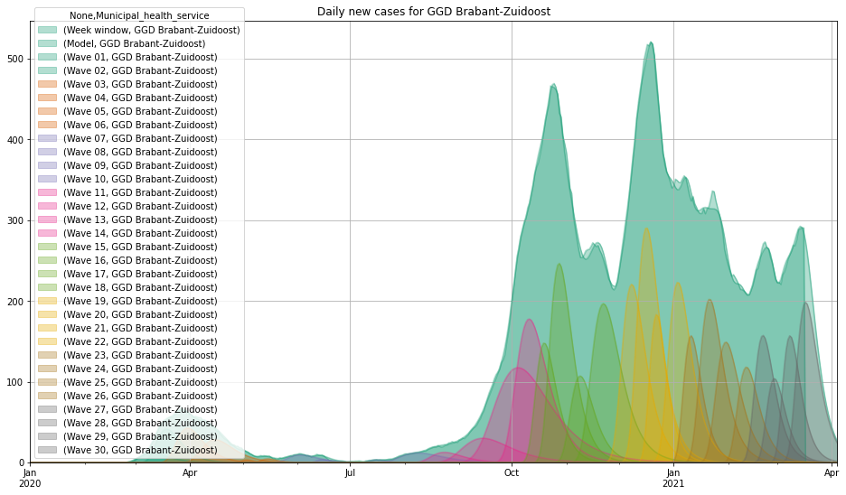

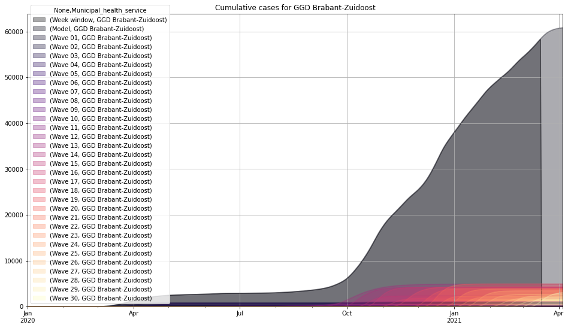

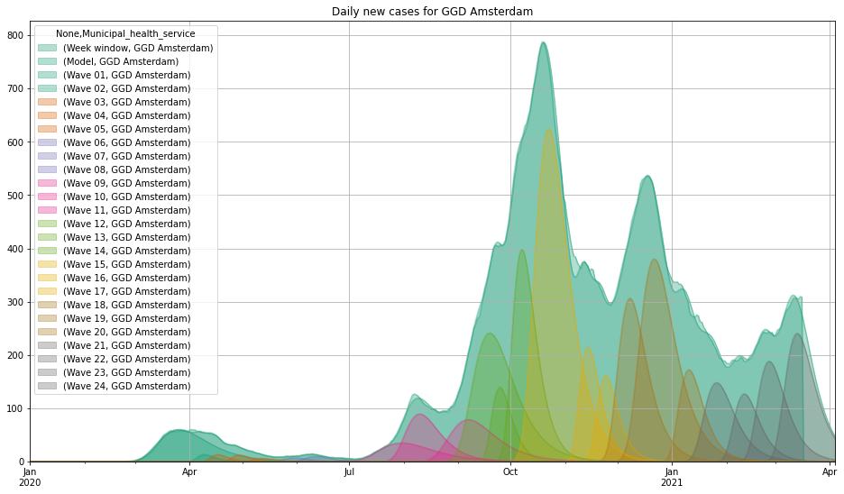

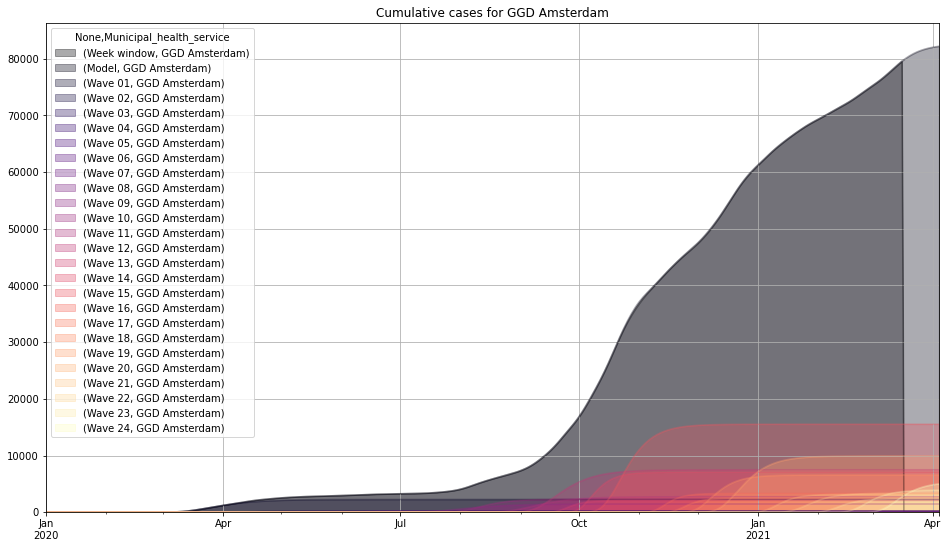

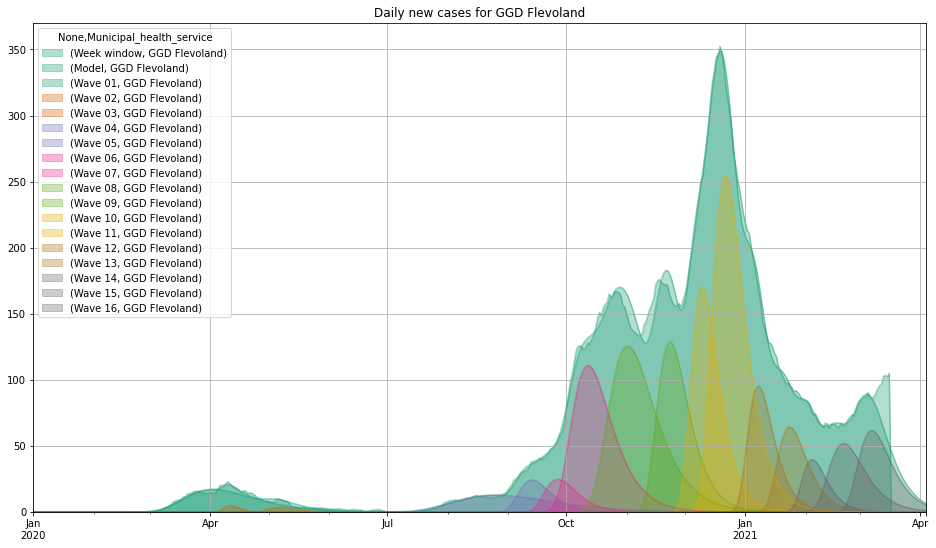

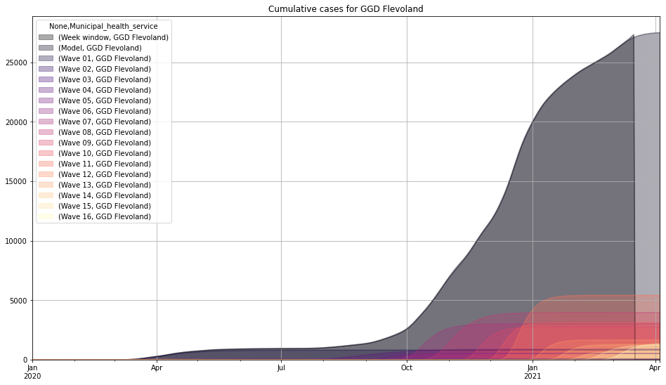

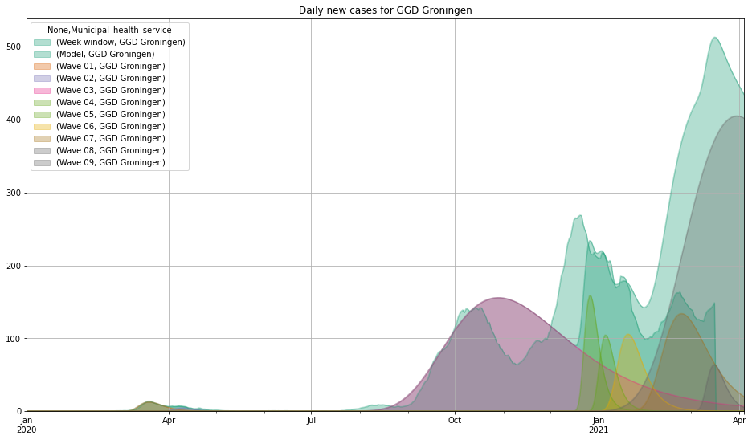

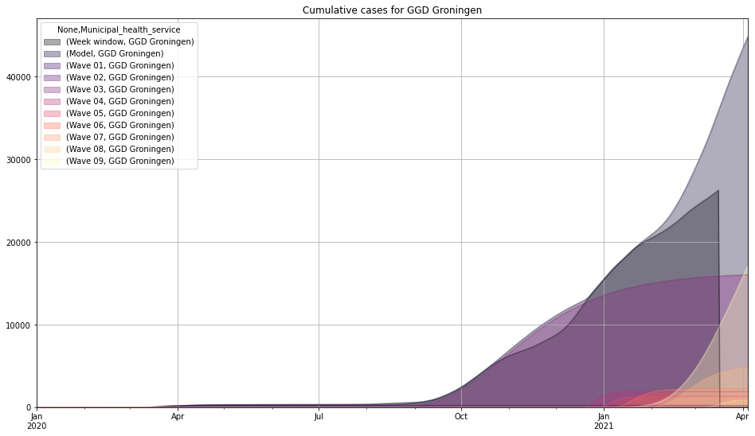

```python
# Select regions to fit.
regions = regions1

# Choose whether to output plots per region.
showplots = True

# region  = 'GGD Brabant Zuid-Oost' and some order important area, i think this is good to choose Brabant-Zuid-Oost
# We will try to measure the case which going up and down and idenfity where
measure  = cases
smeasure = 'Week window' # smoothed
rmeasure = 'rcases'      # remaining
pmeasure = 'Model'       # predicted wave
wmeasure = 'Wave '       # waves
### This one i made the measure for case and week windown to show the smoothed, remaining, ... of corona ware.
for region in regions:
### build the region in region.
    wave = 1
###Apply the variable
    df_geo[(pmeasure, region)] = 0
    df_geo[(smeasure, region)] = df_geo[measure][region].loc[:lastdate].rolling(7).mean()
    df_geo[(rmeasure, region)] = df_geo[smeasure][region]

    plotlist = [(smeasure, region), (pmeasure, region)]

    #countryname = df[df['geoId'] == country]['countriesAndTerritories'].iloc[0]
    #popdata = df[df['geoId'] == country]['popData2019'].iloc[0]

    #mincases = popdata / 1e6
    mincases = 2
    #mincases = df_geo[smeasure][country].sum() / 5000
    #mincases = max(popdata / 1e6, 10)

    print('Running multiple wave analysis for \'{}\''.format(region))
    print('Minimum number of cases is {:1.0f}'.format(mincases))
## Show the line of wave analysis, i got help as reference from outsite.
    while True:
        curwave = wmeasure + str((wave) + 1000)[-2:]
        df_geo[(curwave, region)] = 0

        df_predata = pd.DataFrame({'daynum':df_geo['daynum'],
                                measure:df_geo[rmeasure][region]})
# Choose gumdiv.
        df_predata['gumdiv'] = df_predata[measure] / df_predata[measure].cumsum()
        df_predata = df_predata[(df_predata['gumdiv'] > 0) & (df_predata[measure] > mincases)]

        df_predata['linear'] = np.log(df_predata['gumdiv'])

        df_predata = df_predata[(df_predata['linear'] < -0.5) &
                          (df_predata['linear'] > -3.5)]

        if len(df_predata) <= 1:
            print('--- no data left')
            break
### Luckly not so much data left, it already good data occurrence per day.
        eax = df_predata['daynum'].values.reshape(-1, 1)
        eay = df_predata['linear'].values.reshape(-1, 1)

        #earthmode = Earth()
        #earthmode = Earth(minspan=0)
        earthmode = Earth(minspan=1, penalty=0, endspan=0, thresh=1e-9, check_every=1)
        earthmode.fit(eax, eay)

        df_predata['earth'] = earthmode.predict(eax)
## Day min is the minumum date function min() help us choose the day.
## Day max is the max date function max() help us choose the top day.
        daymin = df_predata['daynum'].min()
        daymax = df_predata['daynum'].max()

        #df_predata['gbgrad'] = np.gradient(df_predata['linear'])
        #df_predata['eagrad'] = np.gradient(df_predata['earth'])
    #In df_predata['linear'] is suitable more on the graph. You can see the gradient too.
        df_predata['gbgrad'] = df_predata['linear'] - df_predata['linear'].shift(1)
        df_predata['eagrad'] = df_predata['earth'] - df_predata['earth'].shift(1)

        fitmod = export.export_python_function(earthmode)
## Apply export python_function(earthmode)
        df_predata['knot'] = ((abs(df_predata['eagrad'] - df_predata['eagrad'].shift(1)) > 1e-6) |
                           (df_predata['daynum'] == (daymin + 1)) |
                           (df_predata['daynum'] == daymax))
        df_predata['daycount'] = df_predata.reset_index().index

        df_knot = df_predata[df_predata['knot']][['daynum', 'daycount', 'eagrad']]
        df_knot['daysdata'] = df_knot['daycount'].shift(-1) - df_knot['daycount']
        df_knot['daystime'] = df_knot['daynum'].shift(-1) - df_knot['daynum']

        df_knot['cand'] = ((df_knot['eagrad'] < -1/77) &
                           (df_knot['daysdata'] >= 3))

        df_knot['since'] = df_knot['daynum'] - daymin
        df_knot['score'] = (df_knot['eagrad'] ** 2) * np.sqrt(df_knot['daysdata'] / np.sqrt(df_knot['since']))
        df_knot['choice'] = df_knot['score'] == df_knot[df_knot['cand']]['score'].max()

        choice = df_knot[df_knot['choice']]
        if len(choice) == 0:
            print('--- no data for wave')
            break

        lower = choice['daynum'].values[0]
        upper = choice['daysdata'].values[0] + lower

        df_predata = df_predata[(df_predata['daynum'] >= lower) &
                          (df_predata['daynum'] <= upper)].copy()

        slope = (fitmod([[upper]])[0] - fitmod([[lower]])[0]) / (upper - lower)
        intercept = fitmod([[lower]])[0] - (lower * slope)
### Slope does matter because they are more linear regression in here.
        beta = - 1 / slope
        mu = beta * (intercept + np.log(beta))

        df_predata['pgumb'] = gumpdf(df_predata['daynum'], beta, mu)
        df_predata['scale'] = df_predata[measure] / df_predata['pgumb']

        final = df_predata['scale'].mean()
        fincv = df_predata['scale'].std() / final
### Findcv on df_predata split to final game.
### Final.std() it is the goal to know cv of standarize / final.
        df_geo[(curwave, region)] = final * gumpdf(df_geo['daynum'], beta, mu)

        peak = df_geo[df_geo[(curwave, region)] == df_geo[(curwave, region)].max()].index.min()
        start = df_geo[(df_geo[(curwave, region)] >= 1) &
                       (df_geo[(curwave, region)].index < peak)].index.min()
        floor = df_geo[(df_geo[(curwave, region)] < 1) &
                       (df_geo[(curwave, region)].index > peak)].index.min()
### Beta wave and MU wave fit the peak from difference size.
### I assigned the wave, mu, betta to reac the beak of start date.
        print('{} beta {:6.3f} mu {:3.0f} fit {:5.3f} peak {} from {} to {} size {:1.0f}'.format(
            curwave, beta, mu, (1 - fincv) ** 2, peak.date(), start.date(), floor.date(), final))

        df_geo[(pmeasure, region)] += df_geo[(curwave, region)]
        df_geo[(rmeasure, region)] -= df_geo[(curwave, region)]
        plotlist += [(curwave, region)]
        wave += 1
# Set the condition for the plot
    if showplots:
        df_geo[plotlist].loc['20200101':'20210404'].plot(
            figsize=(16, 9),
            grid=True,
            kind='area',
            stacked=False,
            alpha=1/3,
            title='Daily new cases for '+region,
            colormap="Dark2")
# Choose the plot type.
        df_geo[plotlist].loc['20200101':'20210404'].cumsum().plot(
            figsize=(16, 9),
            grid=True,
            kind='area',
            stacked=False,
            alpha=1/3,
            title='Cumulative cases for '+region,
            colormap="magma")
```

```python
!wget -N https://data.rivm.nl/covid-19/COVID-19_casus_landelijk.csv
```

```
--2021-04-11 22:28:04--  https://data.rivm.nl/covid-19/COVID-19_casus_landelijk.csv
Resolving data.rivm.nl (data.rivm.nl)... 131.224.250.75, 2001:610:430:ffff::16:198
Connecting to data.rivm.nl (data.rivm.nl)|131.224.250.75|:443... connected.
HTTP request sent, awaiting response... 304 Not Modified
File ‘COVID-19_casus_landelijk.csv’ not modified on server. Omitting download.
```

```python
import pandas as pd
import numpy  as np

df_case = pd.read_csv(
    'COVID-19_casus_landelijk.csv',
    sep=';',
    parse_dates=[0, 1],
    infer_datetime_format=True)
# Import and set date type
df_case.tail(10)
## input by pandas
# df_case_spark = spark.read.options(header='True', inferSchema='True', delimiter=';').csv('COVID-19_casus_landelijk.csv')
# # df_case_spark.show(10)
# from pyspark.sql.types import *

# df_case_spark = df_case_spark.withColumn("Date_file",
# df_case_spark["Date_file"].cast(DateType()))

# df_case_spark = df_case_spark.withColumn("Date_statistics",
# df_case_spark["Date_statistics"].cast(DateType()))
df_case.info()
# df_case_spark.printSchema()
## As a big data input by spark
```

```
<class 'pandas.core.frame.DataFrame'>
RangeIndex: 1350665 entries, 0 to 1350664
Data columns (total 10 columns):
Date_file                   1350665 non-null datetime64[ns]
Date_statistics             1350665 non-null datetime64[ns]
Date_statistics_type        1350665 non-null object
Agegroup                    1350665 non-null object
Sex                         1350665 non-null object
Province                    1350665 non-null object
Hospital_admission          1350665 non-null object
Deceased                    1350665 non-null object
Week_of_death               16770 non-null float64
Municipal_health_service    1350665 non-null object
dtypes: datetime64[ns](2), float64(1), object(7)
memory usage: 103.0+ MB
```

```python
# df_case['period'] = df_case['Date_statistics'].apply(lambda x: x.isocalendar()[1])* 100 + apply(lambda x: x.isocalendar()[1])
# df_case['period']
df_case['period'] = df_case['Date_statistics'].apply(lambda x: x.isocalendar()[0])* 100 + df_case['Date_statistics'].apply(lambda x: x.isocalendar()[1])
df_case['period'] = df_case['period'].apply(str)
df_case['period'] = df_case['period'].apply(lambda x: x[: 4] + 'W' + x[4:])

df_case['group'] = df_case['Sex'] + ' ' + df_case['Agegroup']

df_case.tail(10)
```

|  | Date_file | Date_statistics | Date_statistics_type | Agegroup | Sex | Province | Hospital_admission | Deceased | Week_of_death | Municipal_health_service | period | group |
| --- | --- | --- | --- | --- | --- | --- | --- | --- | --- | --- | --- | --- |
| 1350655 | 2021-04-11 10:00:00 | 2021-04-11 | DPL | 0-9 | Male | Zuid-Holland | Unknown | Unknown | NaN | Dienst Gezondheid & Jeugd ZHZ | 2021W14 | Male 0-9 |
| 1350656 | 2021-04-11 10:00:00 | 2021-04-11 | DPL | 40-49 | Female | Zuid-Holland | Unknown | Unknown | NaN | Dienst Gezondheid & Jeugd ZHZ | 2021W14 | Female 40-49 |
| 1350657 | 2021-04-11 10:00:00 | 2021-04-11 | DPL | 0-9 | Male | Utrecht | Unknown | Unknown | NaN | GGD Regio Utrecht | 2021W14 | Male 0-9 |
| 1350658 | 2021-04-11 10:00:00 | 2021-04-11 | DPL | 50-59 | Female | Overijssel | Unknown | Unknown | NaN | GGD IJsselland | 2021W14 | Female 50-59 |
| 1350659 | 2021-04-11 10:00:00 | 2021-04-11 | DPL | 0-9 | Female | Zuid-Holland | Unknown | Unknown | NaN | Dienst Gezondheid & Jeugd ZHZ | 2021W14 | Female 0-9 |
| 1350660 | 2021-04-11 10:00:00 | 2021-04-11 | DPL | 0-9 | Female | Zuid-Holland | Unknown | Unknown | NaN | Dienst Gezondheid & Jeugd ZHZ | 2021W14 | Female 0-9 |
| 1350661 | 2021-04-11 10:00:00 | 2021-04-11 | DPL | 50-59 | Male | Noord-Brabant | Unknown | Unknown | NaN | GGD Hart voor Brabant | 2021W14 | Male 50-59 |
| 1350662 | 2021-04-11 10:00:00 | 2021-04-11 | DPL | 50-59 | Female | Overijssel | Unknown | Unknown | NaN | GGD IJsselland | 2021W14 | Female 50-59 |
| 1350663 | 2021-04-11 10:00:00 | 2021-04-11 | DPL | 20-29 | Female | Gelderland | Unknown | Unknown | NaN | Veiligheids- en Gezondheidsregio Gelderland-Mi... | 2021W14 | Female 20-29 |
| 1350664 | 2021-04-11 10:00:00 | 2021-04-11 | DPL | 20-29 | Male | Gelderland | Unknown | Unknown | NaN | Veiligheids- en Gezondheidsregio Gelderland-Mi... | 2021W14 | Male 20-29 |

```python
data_df_heat_map = df_case[df_case['Municipal_health_service'] != ''].pivot_table(
    index='period',
    columns='group',
    values='Date_statistics',
    aggfunc='count').fillna(0)

# Select columns to use, optionally subset or use relative numbers
#data_df_heat_map['total'] = data_df_heat_map[data_df_heat_map.columns[0:24]].sum(axis=1)
data_df_heat_map = data_df_heat_map[data_df_heat_map.columns[0:24]]

# setting on the relatie growth numbers
# data_df_heat_map = data_df_heat_map / data_df_heat_map.shift()

data_df_heat_map.tail(5).loc[::-1].transpose()
```

| period group | 2021W14 | 2021W13 | 2021W12 | 2021W11 | 2021W10 |
| --- | --- | --- | --- | --- | --- |
| Female 0-9 | 1051.0 | 1666.0 | 1844.0 | 1752.0 | 1488.0 |
| Female 10-19 | 2359.0 | 3429.0 | 3763.0 | 3599.0 | 2901.0 |
| Female 20-29 | 2714.0 | 3931.0 | 4218.0 | 3923.0 | 3370.0 |
| Female 30-39 | 2269.0 | 3452.0 | 3906.0 | 3738.0 | 3162.0 |
| Female 40-49 | 2256.0 | 3605.0 | 3963.0 | 3688.0 | 3077.0 |
| Female 50-59 | 2223.0 | 3396.0 | 3841.0 | 3488.0 | 3152.0 |
| Female 60-69 | 1181.0 | 1907.0 | 2061.0 | 1928.0 | 1765.0 |
| Female 70-79 | 667.0 | 1080.0 | 1301.0 | 1189.0 | 992.0 |
| Female 80-89 | 195.0 | 325.0 | 419.0 | 412.0 | 439.0 |
| Female 90+ | 52.0 | 68.0 | 93.0 | 95.0 | 128.0 |
| Female <50 | 0.0 | 0.0 | 2.0 | 0.0 | 3.0 |
| Female Unknown | 0.0 | 0.0 | 0.0 | 0.0 | 0.0 |
| Male 0-9 | 1107.0 | 1784.0 | 2071.0 | 1952.0 | 1574.0 |
| Male 10-19 | 2446.0 | 3560.0 | 3952.0 | 3560.0 | 3104.0 |
| Male 20-29 | 2783.0 | 3914.0 | 4195.0 | 3813.0 | 3455.0 |
| Male 30-39 | 2073.0 | 3274.0 | 3504.0 | 3288.0 | 2759.0 |
| Male 40-49 | 2124.0 | 3402.0 | 3637.0 | 3412.0 | 2998.0 |
| Male 50-59 | 2307.0 | 3800.0 | 4065.0 | 3715.0 | 3419.0 |
| Male 60-69 | 1299.0 | 2140.0 | 2300.0 | 2296.0 | 1930.0 |
| Male 70-79 | 724.0 | 1115.0 | 1269.0 | 1123.0 | 991.0 |
| Male 80-89 | 156.0 | 266.0 | 346.0 | 342.0 | 353.0 |
| Male 90+ | 25.0 | 35.0 | 52.0 | 45.0 | 48.0 |
| Male <50 | 0.0 | 0.0 | 1.0 | 0.0 | 1.0 |
| Male Unknown | 0.0 | 0.0 | 0.0 | 0.0 | 0.0 |

#### HeatMap for Corona Time Series on weekly.

According to males and females, this plot depends on the week to week number of cases getting increase.

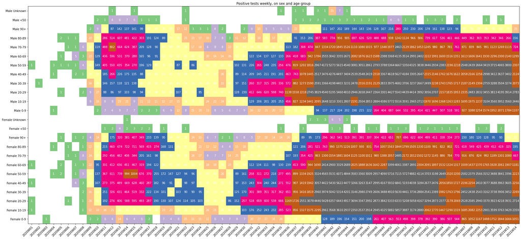

```python
## Define array of row and columns headers
durationsweekly = data_df_heat_map.index
lifetimegroups = data_df_heat_map.columns

## Output size to modified with data size and length
fig, ax = plt.subplots(figsize=(26,12))

heatmap = plt.imshow(
    np.log(data_df_heat_map[data_df_heat_map > 0].loc[:].transpose()),
    cmap='Accent',
    interpolation='None',
    aspect='auto',
    origin='lower')

# Value add to be axis tick label
ax.set_xticks(np.arange(len(durationsweekly)))
ax.set_yticks(np.arange(len(lifetimegroups)))

ax.set_xticklabels(durationsweekly)
ax.set_yticklabels(lifetimegroups)

# X labels diagonally
plt.setp(
    ax.get_xticklabels(),
    rotation=45,
    ha="right",
    rotation_mode="anchor")

# Convert dataframe to numpy dataframe
np_heat = data_df_heat_map.to_numpy()

# Set numbers as text labeles
for i in range(len(durationsweekly)):
    for j in range(len(lifetimegroups)):
        text = ax.text(
            i,
            j,
            int(np_heat[i, j]),
            ha="center",
            va="center",
            color="w")

ax.set_title("Positive tests weekly, on sex and age group")
fig.tight_layout()
plt.show()
```

#### Convert to real plotly heat map.

This perosnally support the project to know exactly for every tiny cell work actively show the number. And by heatmap it able to show the impact of cases.

```python
import plotly.graph_objects as go
import plotly.express as px
import numpy as np

import dash
import dash_core_components as dcc
import dash_html_components as html
import dash_daq as daq
from dash.dependencies import Input, Output, State

#can be consider duration as period time.
durationsweekly = data_df_heat_map.index
lifetimegroups = data_df_heat_map.columns

# df = data_df_heat_map
fig = px.imshow(np.log(data_df_heat_map[data_df_heat_map > 0].loc[:].transpose()))

# Convert dataframe to numpy dataframe
np_heat = data_df_heat_map.to_numpy()

# Set numbers as text labeles
for i in range(len(durationsweekly)):
    for j in range(len(lifetimegroups)):
        text = ax.text(
            i,
            j,
            int(np_heat[i, j]),
            ha="center",
            va="center",
            color="w")

fig.update_layout(
    title="Corona Cases new in NL",
    xaxis_title="Weekly",
    yaxis_title="Lifetime",
    legend_title="Case in NL",
    font=dict(
        family="Courier New, monospace",
        size=12,
        color="Blue"
    )
)
# fig['layout']['yaxis']['autorange'] = "reversed"
# iplot(fig)

fig.show()

## Plot the file heat map into this real case.
```

[interactive chart not shown]

## Result Of This NoteBook

- This one as personal, is going public in Github as Mark Version 1.0. Some changes will apply through other contributions in the future to bring the best level of AI to this Corona Measures WorkNotebook.